# MJSB_1944531_EstadisticaAplicadaG51_parcial3

```python
import numpy as np
import pandas as pd
import scipy.stats as stats
import matplotlib.pyplot as plt

%matplotlib inline
```

```python
churn = pd.read_csv("https://raw.githubusercontent.com/jimmyzac/Estadistica-Aplicada-FCFM-UANL/main/bases_datos/WA_Fn-UseC_-Telco-Customer-Churn.csv")
```

```python
churn.info()
```

```
<class 'pandas.core.frame.DataFrame'>
RangeIndex: 7043 entries, 0 to 7042
Data columns (total 21 columns):
 #   Column            Non-Null Count  Dtype
---  ------            --------------  -----
 0   customerID        7043 non-null   object
 1   gender            7043 non-null   object
 2   SeniorCitizen     7043 non-null   int64
 3   Partner           7043 non-null   object
 4   Dependents        7043 non-null   object
 5   tenure            7043 non-null   int64
 6   PhoneService      7043 non-null   object
 7   MultipleLines     7043 non-null   object
 8   InternetService   7043 non-null   object
 9   OnlineSecurity    7043 non-null   object
 10  OnlineBackup      7043 non-null   object
 11  DeviceProtection  7043 non-null   object
 12  TechSupport       7043 non-null   object
 13  StreamingTV       7043 non-null   object
 14  StreamingMovies   7043 non-null   object
 15  Contract          7043 non-null   object
 16  PaperlessBilling  7043 non-null   object
 17  PaymentMethod     7043 non-null   object
 18  MonthlyCharges    7043 non-null   float64
 19  TotalCharges      7043 non-null   object
 20  Churn             7043 non-null   object
dtypes: float64(1), int64(2), object(18)
memory usage: 1.1+ MB
```

```python
churn['TotalCharges']=pd.to_numeric(churn.TotalCharges,errors='coerce')
```

```python
churn.isnull().sum()
```

```
customerID           0
gender               0
SeniorCitizen        0
Partner              0
Dependents           0
tenure               0
PhoneService         0
MultipleLines        0
InternetService      0
OnlineSecurity       0
OnlineBackup         0
DeviceProtection     0
TechSupport          0
StreamingTV          0
StreamingMovies      0
Contract             0
PaperlessBilling     0
PaymentMethod        0
MonthlyCharges       0
TotalCharges        11
Churn                0
dtype: int64
```

```python
churn[churn.TotalCharges.isna()]
```

|  | customerID | gender | SeniorCitizen | Partner | Dependents | tenure | PhoneService | MultipleLines | InternetService | OnlineSecurity | ... | DeviceProtection | TechSupport | StreamingTV | StreamingMovies | Contract | PaperlessBilling | PaymentMethod | MonthlyCharges | TotalCharges | Churn |
| --- | --- | --- | --- | --- | --- | --- | --- | --- | --- | --- | --- | --- | --- | --- | --- | --- | --- | --- | --- | --- | --- |
| 488 | 4472-LVYGI | Female | 0 | Yes | Yes | 0 | No | No phone service | DSL | Yes | ... | Yes | Yes | Yes | No | Two year | Yes | Bank transfer (automatic) | 52.55 | NaN | No |
| 753 | 3115-CZMZD | Male | 0 | No | Yes | 0 | Yes | No | No | No internet service | ... | No internet service | No internet service | No internet service | No internet service | Two year | No | Mailed check | 20.25 | NaN | No |
| 936 | 5709-LVOEQ | Female | 0 | Yes | Yes | 0 | Yes | No | DSL | Yes | ... | Yes | No | Yes | Yes | Two year | No | Mailed check | 80.85 | NaN | No |
| 1082 | 4367-NUYAO | Male | 0 | Yes | Yes | 0 | Yes | Yes | No | No internet service | ... | No internet service | No internet service | No internet service | No internet service | Two year | No | Mailed check | 25.75 | NaN | No |
| 1340 | 1371-DWPAZ | Female | 0 | Yes | Yes | 0 | No | No phone service | DSL | Yes | ... | Yes | Yes | Yes | No | Two year | No | Credit card (automatic) | 56.05 | NaN | No |
| 3331 | 7644-OMVMY | Male | 0 | Yes | Yes | 0 | Yes | No | No | No internet service | ... | No internet service | No internet service | No internet service | No internet service | Two year | No | Mailed check | 19.85 | NaN | No |
| 3826 | 3213-VVOLG | Male | 0 | Yes | Yes | 0 | Yes | Yes | No | No internet service | ... | No internet service | No internet service | No internet service | No internet service | Two year | No | Mailed check | 25.35 | NaN | No |
| 4380 | 2520-SGTTA | Female | 0 | Yes | Yes | 0 | Yes | No | No | No internet service | ... | No internet service | No internet service | No internet service | No internet service | Two year | No | Mailed check | 20.00 | NaN | No |
| 5218 | 2923-ARZLG | Male | 0 | Yes | Yes | 0 | Yes | No | No | No internet service | ... | No internet service | No internet service | No internet service | No internet service | One year | Yes | Mailed check | 19.70 | NaN | No |
| 6670 | 4075-WKNIU | Female | 0 | Yes | Yes | 0 | Yes | Yes | DSL | No | ... | Yes | Yes | Yes | No | Two year | No | Mailed check | 73.35 | NaN | No |
| 6754 | 2775-SEFEE | Male | 0 | No | Yes | 0 | Yes | Yes | DSL | Yes | ... | No | Yes | No | No | Two year | Yes | Bank transfer (automatic) | 61.90 | NaN | No |

11 rows × 21 columns

```python
churn[churn["tenure"] == 0]
```

|  | customerID | gender | SeniorCitizen | Partner | Dependents | tenure | PhoneService | MultipleLines | InternetService | OnlineSecurity | ... | DeviceProtection | TechSupport | StreamingTV | StreamingMovies | Contract | PaperlessBilling | PaymentMethod | MonthlyCharges | TotalCharges | Churn |
| --- | --- | --- | --- | --- | --- | --- | --- | --- | --- | --- | --- | --- | --- | --- | --- | --- | --- | --- | --- | --- | --- |
| 488 | 4472-LVYGI | Female | 0 | Yes | Yes | 0 | No | No phone service | DSL | Yes | ... | Yes | Yes | Yes | No | Two year | Yes | Bank transfer (automatic) | 52.55 | NaN | No |
| 753 | 3115-CZMZD | Male | 0 | No | Yes | 0 | Yes | No | No | No internet service | ... | No internet service | No internet service | No internet service | No internet service | Two year | No | Mailed check | 20.25 | NaN | No |
| 936 | 5709-LVOEQ | Female | 0 | Yes | Yes | 0 | Yes | No | DSL | Yes | ... | Yes | No | Yes | Yes | Two year | No | Mailed check | 80.85 | NaN | No |
| 1082 | 4367-NUYAO | Male | 0 | Yes | Yes | 0 | Yes | Yes | No | No internet service | ... | No internet service | No internet service | No internet service | No internet service | Two year | No | Mailed check | 25.75 | NaN | No |
| 1340 | 1371-DWPAZ | Female | 0 | Yes | Yes | 0 | No | No phone service | DSL | Yes | ... | Yes | Yes | Yes | No | Two year | No | Credit card (automatic) | 56.05 | NaN | No |
| 3331 | 7644-OMVMY | Male | 0 | Yes | Yes | 0 | Yes | No | No | No internet service | ... | No internet service | No internet service | No internet service | No internet service | Two year | No | Mailed check | 19.85 | NaN | No |
| 3826 | 3213-VVOLG | Male | 0 | Yes | Yes | 0 | Yes | Yes | No | No internet service | ... | No internet service | No internet service | No internet service | No internet service | Two year | No | Mailed check | 25.35 | NaN | No |
| 4380 | 2520-SGTTA | Female | 0 | Yes | Yes | 0 | Yes | No | No | No internet service | ... | No internet service | No internet service | No internet service | No internet service | Two year | No | Mailed check | 20.00 | NaN | No |
| 5218 | 2923-ARZLG | Male | 0 | Yes | Yes | 0 | Yes | No | No | No internet service | ... | No internet service | No internet service | No internet service | No internet service | One year | Yes | Mailed check | 19.70 | NaN | No |
| 6670 | 4075-WKNIU | Female | 0 | Yes | Yes | 0 | Yes | Yes | DSL | No | ... | Yes | Yes | Yes | No | Two year | No | Mailed check | 73.35 | NaN | No |
| 6754 | 2775-SEFEE | Male | 0 | No | Yes | 0 | Yes | Yes | DSL | Yes | ... | No | Yes | No | No | Two year | Yes | Bank transfer (automatic) | 61.90 | NaN | No |

11 rows × 21 columns

```python
churn= churn.dropna(subset=['TotalCharges'])
```

```python
churn.drop_duplicates(inplace=True)
```

```python
#creamosuna lista de esas variables
sino=['Partner','Dependents','Churn']
for i in sino:
    churn[i]=churn[i].map({'Yes':1,'No':0})
```

```python
churn.describe()
```

|  | SeniorCitizen | Partner | Dependents | tenure | MonthlyCharges | TotalCharges | Churn |
| --- | --- | --- | --- | --- | --- | --- | --- |
| count | 7032.000000 | 7032.000000 | 7032.000000 | 7032.000000 | 7032.000000 | 7032.000000 | 7032.000000 |
| mean | 0.162400 | 0.482509 | 0.298493 | 32.421786 | 64.798208 | 2283.300441 | 0.265785 |
| std | 0.368844 | 0.499729 | 0.457629 | 24.545260 | 30.085974 | 2266.771362 | 0.441782 |
| min | 0.000000 | 0.000000 | 0.000000 | 1.000000 | 18.250000 | 18.800000 | 0.000000 |
| 25% | 0.000000 | 0.000000 | 0.000000 | 9.000000 | 35.587500 | 401.450000 | 0.000000 |
| 50% | 0.000000 | 0.000000 | 0.000000 | 29.000000 | 70.350000 | 1397.475000 | 0.000000 |
| 75% | 0.000000 | 1.000000 | 1.000000 | 55.000000 | 89.862500 | 3794.737500 | 1.000000 |
| max | 1.000000 | 1.000000 | 1.000000 | 72.000000 | 118.750000 | 8684.800000 | 1.000000 |

#### Mean es visto como el punto de equilibrio del conjunto de datos. Para la desviacion estandar podemos ver dados sus valores, que tan dispersos estan los datos por alrededor de la media. En cuanto al minimo y maximo en algunas variables vemos que estos son 0 y 1 ya que son solo los valores que toman, en otros si vemos valores diferentes de cual es el dato mayor y cual el menor. Tambien tenemos los valores de los cuartiles, de 25, 50 y 75 que sirve para evaluar rápidamente la dispersión y la tendencia central de un conjunto de datos, esto nos ayuda a comprender los datos.

```python
churn.head(10)
```

|  | customerID | gender | SeniorCitizen | Partner | Dependents | tenure | PhoneService | MultipleLines | InternetService | OnlineSecurity | ... | DeviceProtection | TechSupport | StreamingTV | StreamingMovies | Contract | PaperlessBilling | PaymentMethod | MonthlyCharges | TotalCharges | Churn |
| --- | --- | --- | --- | --- | --- | --- | --- | --- | --- | --- | --- | --- | --- | --- | --- | --- | --- | --- | --- | --- | --- |
| 0 | 7590-VHVEG | Female | 0 | 1 | 0 | 1 | No | No phone service | DSL | No | ... | No | No | No | No | Month-to-month | Yes | Electronic check | 29.85 | 29.85 | 0 |
| 1 | 5575-GNVDE | Male | 0 | 0 | 0 | 34 | Yes | No | DSL | Yes | ... | Yes | No | No | No | One year | No | Mailed check | 56.95 | 1889.50 | 0 |
| 2 | 3668-QPYBK | Male | 0 | 0 | 0 | 2 | Yes | No | DSL | Yes | ... | No | No | No | No | Month-to-month | Yes | Mailed check | 53.85 | 108.15 | 1 |
| 3 | 7795-CFOCW | Male | 0 | 0 | 0 | 45 | No | No phone service | DSL | Yes | ... | Yes | Yes | No | No | One year | No | Bank transfer (automatic) | 42.30 | 1840.75 | 0 |
| 4 | 9237-HQITU | Female | 0 | 0 | 0 | 2 | Yes | No | Fiber optic | No | ... | No | No | No | No | Month-to-month | Yes | Electronic check | 70.70 | 151.65 | 1 |
| 5 | 9305-CDSKC | Female | 0 | 0 | 0 | 8 | Yes | Yes | Fiber optic | No | ... | Yes | No | Yes | Yes | Month-to-month | Yes | Electronic check | 99.65 | 820.50 | 1 |
| 6 | 1452-KIOVK | Male | 0 | 0 | 1 | 22 | Yes | Yes | Fiber optic | No | ... | No | No | Yes | No | Month-to-month | Yes | Credit card (automatic) | 89.10 | 1949.40 | 0 |
| 7 | 6713-OKOMC | Female | 0 | 0 | 0 | 10 | No | No phone service | DSL | Yes | ... | No | No | No | No | Month-to-month | No | Mailed check | 29.75 | 301.90 | 0 |
| 8 | 7892-POOKP | Female | 0 | 1 | 0 | 28 | Yes | Yes | Fiber optic | No | ... | Yes | Yes | Yes | Yes | Month-to-month | Yes | Electronic check | 104.80 | 3046.05 | 1 |
| 9 | 6388-TABGU | Male | 0 | 0 | 1 | 62 | Yes | No | DSL | Yes | ... | No | No | No | No | One year | No | Bank transfer (automatic) | 56.15 | 3487.95 | 0 |

10 rows × 21 columns

```python
promediosupervivencia = churn['tenure'].mean()
promediosupervivencia
```

```
32.421786120591584
```

```python
pip install lifelines
```

```python
from lifelines import KaplanMeierFitter
kmf = KaplanMeierFitter()
```

| timeline | Funcion Supervivencia |
| --- | --- |
| 0.0 | 1.000000 |
| 1.0 | 0.945961 |
| 2.0 | 0.927835 |
| 3.0 | 0.913725 |
| 4.0 | 0.901045 |
| ... | ... |
| 68.0 | 0.626858 |
| 69.0 | 0.620135 |
| 70.0 | 0.609657 |
| 71.0 | 0.602781 |
| 72.0 | 0.592790 |

73 rows × 1 columns

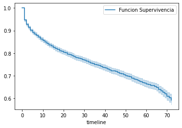

```python
kmf.fit(churn['tenure'], churn['Churn'], label = "Funcion Supervivencia").plot()
kmf.survival_function_
```

```python
from lifelines.utils import median_survival_times

median_ = kmf.median_survival_time_
median_
```

```
inf
```

```python
median_value = np.percentile(churn['MonthlyCharges'], 50)
print(median_value)
```

```
70.35
```

```python
paganmucho = churn[churn['MonthlyCharges'] > median_value]
paganpoco = churn[churn['MonthlyCharges'] <= median_value]
```

```python
tenuremucho = paganmucho['tenure']
churnmucho = paganmucho['Churn']

tenurepoco = paganpoco['tenure']
churnpoco = paganpoco['Churn']
```

| timeline | Pagan mucho |
| --- | --- |
| 0.0 | 1.000000 |
| 1.0 | 0.957301 |
| 2.0 | 0.938069 |
| 3.0 | 0.923023 |
| 4.0 | 0.907532 |
| ... | ... |
| 68.0 | 0.556350 |
| 69.0 | 0.547359 |
| 70.0 | 0.536163 |
| 71.0 | 0.528777 |
| 72.0 | 0.518286 |

73 rows × 1 columns

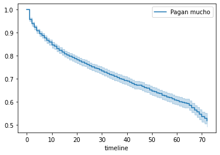

```python
kmf.fit(tenuremucho, churnmucho, label = "Pagan mucho").plot()
kmf.survival_function_
```

| timeline | Pagan poco |
| --- | --- |
| 0.0 | 1.000000 |
| 1.0 | 0.934641 |
| 2.0 | 0.917669 |
| 3.0 | 0.904555 |
| 4.0 | 0.894942 |
| ... | ... |
| 68.0 | 0.752381 |
| 69.0 | 0.752381 |
| 70.0 | 0.745249 |
| 71.0 | 0.740840 |
| 72.0 | 0.734105 |

73 rows × 1 columns

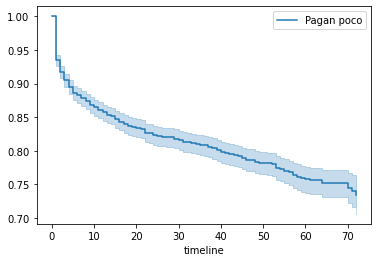

```python
kmf.fit(tenurepoco, churnpoco, label = "Pagan poco").plot()
kmf.survival_function_
```

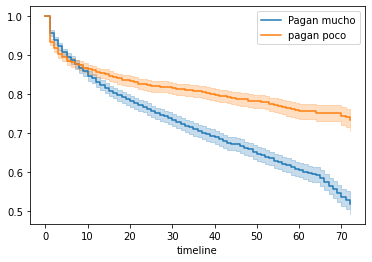

```python
ax = plt.subplot(111)
ax = kmf.fit(tenuremucho, churnmucho, label = "Pagan mucho").plot(ax=ax)
ax = kmf.fit(tenurepoco, churnpoco, label = "pagan poco").plot(ax=ax)
```

#### Con base en la grafica podemos notar que la funcion de supervivencia de los que pagan poco es mayor a la de los que pagan mucho por lo que podemos asumir que despues de un tiempo, las personas que mas pagan cancelan su suscripcion ya que lo ven como un gasto grande, mientras que los que pagan poco siguen con su suscripcion ya que no lo ven como un pago tan grande. Por lo tanto, lo que asume la empresa es verdad.

```python
from lifelines.statistics import logrank_test
```

### H0: Las funciones de superviencia son iguales Ha: Las funciones de supervivencia son diferentes

```python
results = logrank_test(tenuremucho, tenurepoco, event_observed_A = churnmucho, event_observed_B = churnpoco)
results.print_summary()
```

| t_0 | -1 |
| --- | --- |
| null_distribution | chi squared |
| degrees_of_freedom | 1 |
| test_name | logrank_test |

|  | test_statistic | p | -log2(p) |
| --- | --- | --- | --- |
| 0 | 91.85 | <0.005 | 69.86 |

```python
dsl = churn[churn['InternetService'] == "DSL"]
fiber = churn[churn['InternetService'] == "Fiber optic"]
no = churn[churn['InternetService'] == "No"]
```

```python
tenuredsl = dsl['tenure']
churndsl = dsl['Churn']

tenurefiber = fiber['tenure']
churnfiber = fiber['Churn']

tenureno = no['tenure']
churno = no['Churn']
```

| timeline | DSL |
| --- | --- |
| 0.0 | 1.000000 |
| 1.0 | 0.950745 |
| 2.0 | 0.932196 |
| 3.0 | 0.918138 |
| 4.0 | 0.906947 |
| ... | ... |
| 68.0 | 0.745778 |
| 69.0 | 0.743086 |
| 70.0 | 0.737069 |
| 71.0 | 0.733289 |
| 72.0 | 0.722262 |

73 rows × 1 columns

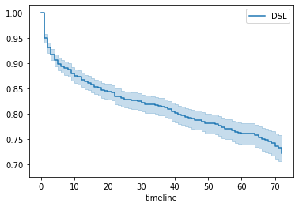

```python
kmf.fit(tenuredsl, churndsl, label = "DSL").plot()
kmf.survival_function_
```

| timeline | Fiber Optic |
| --- | --- |
| 0.0 | 1.000000 |
| 1.0 | 0.934432 |
| 2.0 | 0.910262 |
| 3.0 | 0.891740 |
| 4.0 | 0.873315 |
| ... | ... |
| 68.0 | 0.461805 |
| 69.0 | 0.451672 |
| 70.0 | 0.436996 |
| 71.0 | 0.427497 |
| 72.0 | 0.417006 |

73 rows × 1 columns

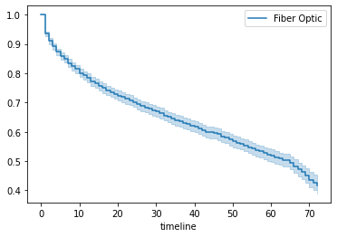

```python
kmf.fit(tenurefiber, churnfiber, label = "Fiber Optic").plot()
kmf.survival_function_
```

| timeline | No |
| --- | --- |
| 0.0 | 1.000000 |
| 1.0 | 0.961842 |
| 2.0 | 0.957580 |
| 3.0 | 0.953184 |
| 4.0 | 0.950929 |
| ... | ... |
| 68.0 | 0.901539 |
| 69.0 | 0.901539 |
| 70.0 | 0.901539 |
| 71.0 | 0.901539 |
| 72.0 | 0.901539 |

73 rows × 1 columns

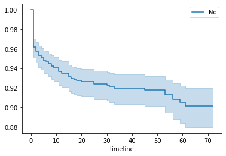

```python
kmf.fit(tenureno, churno, label = "No").plot()
kmf.survival_function_
```

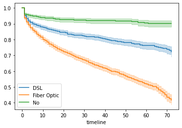

```python
ax = plt.subplot(111)
ax = kmf.fit(tenuredsl, churndsl, label = "DSL").plot(ax=ax)
ax = kmf.fit(tenurefiber, churnfiber, label = "Fiber Optic").plot(ax=ax)
ax = kmf.fit(tenureno, churno, label = "No").plot(ax=ax)
```

### Con base en la grafica nos podemos dar cuenta que si influye en que si se tiene internet contratado con la empresa, los usuarios suspenden el servicio. Esto se puede dar ya que quiza el internet de la empresa no es de la mejor calidad o simplemente se les hace muy costoso adquirir el servicios ya que el que mas abandona es el de la fibra optica ya que es mas casotoso que el otro tipo de internet.

```python
categoricas= ['gender','PhoneService','MultipleLines', 'InternetService','OnlineSecurity','OnlineBackup','DeviceProtection','TechSupport','StreamingTV','StreamingMovies','Contract','PaperlessBilling', 'PaymentMethod']
```

```python
for i in categoricas:
    churn[i] = churn[i].astype('category')
    churn[i] =churn[i].cat.codes
```

```python
churn
```

|  | customerID | gender | SeniorCitizen | Partner | Dependents | tenure | PhoneService | MultipleLines | InternetService | OnlineSecurity | ... | DeviceProtection | TechSupport | StreamingTV | StreamingMovies | Contract | PaperlessBilling | PaymentMethod | MonthlyCharges | TotalCharges | Churn |
| --- | --- | --- | --- | --- | --- | --- | --- | --- | --- | --- | --- | --- | --- | --- | --- | --- | --- | --- | --- | --- | --- |
| 0 | 7590-VHVEG | 0 | 0 | 1 | 0 | 1 | 0 | 1 | 0 | 0 | ... | 0 | 0 | 0 | 0 | 0 | 1 | 2 | 29.85 | 29.85 | 0 |
| 1 | 5575-GNVDE | 1 | 0 | 0 | 0 | 34 | 1 | 0 | 0 | 2 | ... | 2 | 0 | 0 | 0 | 1 | 0 | 3 | 56.95 | 1889.50 | 0 |
| 2 | 3668-QPYBK | 1 | 0 | 0 | 0 | 2 | 1 | 0 | 0 | 2 | ... | 0 | 0 | 0 | 0 | 0 | 1 | 3 | 53.85 | 108.15 | 1 |
| 3 | 7795-CFOCW | 1 | 0 | 0 | 0 | 45 | 0 | 1 | 0 | 2 | ... | 2 | 2 | 0 | 0 | 1 | 0 | 0 | 42.30 | 1840.75 | 0 |
| 4 | 9237-HQITU | 0 | 0 | 0 | 0 | 2 | 1 | 0 | 1 | 0 | ... | 0 | 0 | 0 | 0 | 0 | 1 | 2 | 70.70 | 151.65 | 1 |
| ... | ... | ... | ... | ... | ... | ... | ... | ... | ... | ... | ... | ... | ... | ... | ... | ... | ... | ... | ... | ... | ... |
| 7038 | 6840-RESVB | 1 | 0 | 1 | 1 | 24 | 1 | 2 | 0 | 2 | ... | 2 | 2 | 2 | 2 | 1 | 1 | 3 | 84.80 | 1990.50 | 0 |
| 7039 | 2234-XADUH | 0 | 0 | 1 | 1 | 72 | 1 | 2 | 1 | 0 | ... | 2 | 0 | 2 | 2 | 1 | 1 | 1 | 103.20 | 7362.90 | 0 |
| 7040 | 4801-JZAZL | 0 | 0 | 1 | 1 | 11 | 0 | 1 | 0 | 2 | ... | 0 | 0 | 0 | 0 | 0 | 1 | 2 | 29.60 | 346.45 | 0 |
| 7041 | 8361-LTMKD | 1 | 1 | 1 | 0 | 4 | 1 | 2 | 1 | 0 | ... | 0 | 0 | 0 | 0 | 0 | 1 | 3 | 74.40 | 306.60 | 1 |
| 7042 | 3186-AJIEK | 1 | 0 | 0 | 0 | 66 | 1 | 0 | 1 | 2 | ... | 2 | 2 | 2 | 2 | 2 | 1 | 0 | 105.65 | 6844.50 | 0 |

7032 rows × 21 columns

```python
from lifelines import CoxPHFitter
cph = CoxPHFitter()
```

```python
churn.drop('customerID', inplace=True, axis=1)
```

```python
cph = CoxPHFitter()
cph.fit(churn, duration_col='tenure', event_col='Churn')
cph.print_summary()
```

| model | lifelines.CoxPHFitter |
| --- | --- |
| duration col | 'tenure' |
| event col | 'Churn' |
| baseline estimation | breslow |
| number of observations | 7032 |
| number of events observed | 1869 |
| partial log-likelihood | -12679.32 |
| time fit was run | 2022-05-17 00:48:55 UTC |

|  | coef | exp(coef) | se(coef) | coef lower 95% | coef upper 95% | exp(coef) lower 95% | exp(coef) upper 95% | cmp to | z | p | -log2(p) |
| --- | --- | --- | --- | --- | --- | --- | --- | --- | --- | --- | --- |
| gender | -0.04 | 0.96 | 0.05 | -0.13 | 0.05 | 0.88 | 1.05 | 0.00 | -0.91 | 0.36 | 1.46 |
| SeniorCitizen | 0.04 | 1.04 | 0.06 | -0.07 | 0.15 | 0.93 | 1.16 | 0.00 | 0.69 | 0.49 | 1.02 |
| Partner | -0.18 | 0.84 | 0.05 | -0.28 | -0.07 | 0.75 | 0.93 | 0.00 | -3.20 | <0.005 | 9.48 |
| Dependents | -0.09 | 0.91 | 0.07 | -0.23 | 0.04 | 0.80 | 1.04 | 0.00 | -1.33 | 0.18 | 2.45 |
| PhoneService | -0.21 | 0.81 | 0.12 | -0.44 | 0.02 | 0.64 | 1.02 | 0.00 | -1.81 | 0.07 | 3.84 |
| MultipleLines | -0.08 | 0.92 | 0.03 | -0.13 | -0.03 | 0.88 | 0.97 | 0.00 | -2.97 | <0.005 | 8.37 |
| InternetService | -0.20 | 0.82 | 0.06 | -0.31 | -0.08 | 0.73 | 0.92 | 0.00 | -3.39 | <0.005 | 10.46 |
| OnlineSecurity | -0.22 | 0.80 | 0.03 | -0.29 | -0.16 | 0.75 | 0.85 | 0.00 | -6.69 | <0.005 | 35.40 |
| OnlineBackup | -0.15 | 0.86 | 0.03 | -0.20 | -0.09 | 0.82 | 0.91 | 0.00 | -5.45 | <0.005 | 24.24 |
| DeviceProtection | -0.07 | 0.93 | 0.03 | -0.13 | -0.02 | 0.88 | 0.98 | 0.00 | -2.72 | 0.01 | 7.25 |
| TechSupport | -0.16 | 0.85 | 0.03 | -0.23 | -0.10 | 0.80 | 0.91 | 0.00 | -5.02 | <0.005 | 20.90 |
| StreamingTV | -0.09 | 0.91 | 0.03 | -0.15 | -0.04 | 0.86 | 0.96 | 0.00 | -3.29 | <0.005 | 9.98 |
| StreamingMovies | -0.09 | 0.91 | 0.03 | -0.15 | -0.04 | 0.86 | 0.96 | 0.00 | -3.25 | <0.005 | 9.77 |
| Contract | -1.63 | 0.20 | 0.08 | -1.79 | -1.47 | 0.17 | 0.23 | 0.00 | -19.77 | <0.005 | 286.45 |
| PaperlessBilling | 0.15 | 1.17 | 0.06 | 0.04 | 0.26 | 1.04 | 1.30 | 0.00 | 2.72 | 0.01 | 7.27 |
| PaymentMethod | 0.20 | 1.22 | 0.03 | 0.15 | 0.25 | 1.16 | 1.29 | 0.00 | 7.31 | <0.005 | 41.71 |
| MonthlyCharges | 0.06 | 1.06 | 0.00 | 0.06 | 0.07 | 1.06 | 1.07 | 0.00 | 27.12 | <0.005 | 535.51 |
| TotalCharges | -0.00 | 1.00 | 0.00 | -0.00 | -0.00 | 1.00 | 1.00 | 0.00 | -38.96 | <0.005 | inf |

| Concordance | 0.93 |
| --- | --- |
| Partial AIC | 25394.64 |
| log-likelihood ratio test | 5947.44 on 18 df |
| -log2(p) of ll-ratio test | inf |

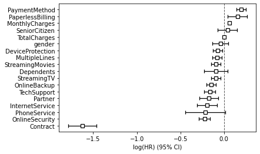

```python
cph.plot()
```

### H0: La variable no afecta el riesgo de sufrir el evento Ha: la variable afecta el riesgo de sufrir el evento

#### * Para la variable 'gender' como pvalor = 0.36 no se rechaza Ho. Por lo tanto la variable 'gender' no afecta el riesgo de sufrir el evento. Esto disminuye en un 4%

#### * Para la variable 'SeniorCitizen' como pvalor = 0.49 no se rechaza Ho. Por lo tanto la variable 'SeniorCitizen' no afecta el riesgo de sufrir el evento. Esto aumenta en un 4%

#### * Para la variable 'Partner' como pvalor = 0.005 se rechaza Ho. Por lo tanto la variable 'Partner' afecta el riesgo de sufrir el evento. Esto disminuye en un 16%

#### * Para la variable 'Dependents' como pvalor = 0.18 no se rechaza Ho. Por lo tanto la variable 'Dependents' no afecta el riesgo de sufrir el evento. Esto disminuye en un 9%

#### * Para la variable 'PhoneService' como pvalor = 0.07 no se rechaza Ho. Por lo tanto la variable 'PhoneService' no afecta el riesgo de sufrir el evento. Esto disminuye en un 19%

#### * Para la variable 'MultipleLines' como pvalor = 0.005 se rechaza Ho. Por lo tanto la variable 'MultipleLines' afecta el riesgo de sufrir el evento. Esto disminuye en un 8%

#### * Para la variable 'InternetService' como pvalor = 0.005 se rechaza Ho. Por lo tanto la variable 'InternetService' afecta el riesgo de sufrir el evento. Esto disminuye en un 18%

#### * Para la variable 'OnlineSecurity' como pvalor = 0.005 se rechaza Ho. Por lo tanto la variable 'OnlineSecurity' afecta el riesgo de sufrir el evento. Esto disminuye en un 20%

#### * Para la variable 'OnlineBackup' como pvalor = 0.005 se rechaza Ho. Por lo tanto la variable 'OnlineBackup' afecta el riesgo de sufrir el evento. Esto disminuye en un 14%

#### * Para la variable 'DeviceProtection' como pvalor = 0.01 se rechaza Ho. Por lo tanto la variable 'DeviceProtection' afecta el riesgo de sufrir el evento. Esto disminuye en un 7%

#### * Para la variable 'TechSupport' como pvalor = 0.005 se rechaza Ho. Por lo tanto la variable 'TechSupport' afecta el riesgo de sufrir el evento. Esto disminuye en un 15%

#### * Para la variable 'StreamingTV' como pvalor = 0.005 se rechaza Ho. Por lo tanto la variable 'StreamingTV' afecta el riesgo de sufrir el evento. Esto disminuye en un 9%

#### * Para la variable 'StreamingMovies' como pvalor = 0.005 se rechaza Ho. Por lo tanto la variable 'StreamingMovies' afecta el riesgo de sufrir el evento. Esto disminuye en un 9%

#### * Para la variable 'Contract' como pvalor = 0.005 se rechaza Ho. Por lo tanto la variable 'Contract' afecta el riesgo de sufrir el evento. Esto disminuye en un 80%

#### * Para la variable 'PaperlessBilling' como pvalor = 0.01 se rechaza Ho. Por lo tanto la variable 'PaperlessBilling' afecta el riesgo de sufrir el evento. Esto aumenta en un 17%

#### * Para la variable 'PaymentMethod' como pvalor = 0.005 se rechaza Ho. Por lo tanto la variable 'PaymentMethod' afecta el riesgo de sufrir el evento. Esto aumenta en un 22%

#### * Para la variable 'MonthlyCharges' como pvalor = 0.005 se rechaza Ho. Por lo tanto la variable 'MonthlyCharges' afecta el riesgo de sufrir el evento. Esto aumenta en un 6%

#### * Para la variable 'TotalCharges' como pvalor = 0.005 se rechaza Ho. Por lo tanto la variable 'TotalCharges' afecta el riesgo de sufrir el evento. Esto no aumenta ni disminuye

### Observando los resultados de MonthlyCharges junto con los resultados de la funcion de supervivencia, estos si coinciden ya que con la funcion de supervivencia vemos que mientras mas pagan mas se sufre el evento y en este caso la variable MonthlyCharges afecta el riesgo de sufrir el evento

## Las variables Partner, multilple lines, internet service, online security, online backup, deviceprotection, tech support, streamingTv, streaming movies, contract, paperlessBilling, PaymentMethod, MonthlyCharges, TotalCharges son las variables que afectan el riesgo de sufrir el evento. Como podemos ver son variables que se asume generan mas costos. Como vimos en la grafica de supervivencia, los clientes suelen cancelar la suscripcion ya que llegan a pagar mucho y es aqui donde la variable partner puede tambien influir, ya que al no tener a alguien con quien compartir gastos, la persona que hace el pago siente que es un gasto grande. El PaymentMethod tambien influye pues muchas veces los clientes pueden llegar a olvidar hacer el pago o no guardar esa cantidad en sus tarjetas lo que hace que no se genere el pago y por ende no se sigue con el servicio por falta de pago. Incluso tambien la variable Contract tiene mucho enfasis ya que si no se vuelve a contrar el servicio, damos por hecho que se sufre el evento. Podemos concluir que el hecho de que se sufra el evento es por cuestiones de pago, lo que podria hacer la empresa es brindarle a sus clientes costos menores pero siempre con una buena calidad y que aun asi la empresa no termine perdiendo.